# Case Study I

Emily Schmidt and Genta Mehmeti

2023-03-12

```r
# Clear the database
rm(list=ls())
```

### Load Packages and Data

```r
library(dplyr)
library(ggplot2)
library(readr) # Imports Excel csv
library(naniar) # Missing values
library(tidyverse)
library(caret)
library(kableExtra) # Tables
library(cowplot) # Arrange plots into a grid and label them
library(GGally) # Allows to build a great scatterplot matrix
library(car) # VIF

source("VIF.R")
```

### Data Exploration

```r
kable(head(helio)) %>% kable_classic() %>%
  kableExtra::kable_styling(bootstrap_options = c("striped", "hover", "condensed","responsive")) %>%
  kable_styling(position = "center") # Use kable to design table
```

| number_of_solar_panels | manufacturing_cost |
| --- | --- |
| 100 | 1250.0 |
| 200 | 1108.7 |
| 300 | 1053.5 |
| 400 | 1033.4 |
| 500 | 989.8 |
| 600 | 999.0 |

```r
str(helio) # Structure of object/ Type of variables
```

```
## spc_tbl_ [22 × 2] (S3: spec_tbl_df/tbl_df/tbl/data.frame)
##  $ number_of_solar_panels: num [1:22] 100 200 300 400 500 600 700 800 900 1000 ...
##  $ manufacturing_cost    : num [1:22] 1250 1109 1054 1033 990 ...
##  - attr(*, "spec")=
##   .. cols(
##   ..   number_of_solar_panels = col_double(),
##   ..   manufacturing_cost = col_double()
##   .. )
##  - attr(*, "problems")=<externalptr>
```

```r
dim(helio) # Dimensions of data
```

```
## [1] 22  2
```

```r
summary(helio) # Produce result summaries of all variables
```

```
##  number_of_solar_panels manufacturing_cost
##  Min.   : 100           Min.   : 765.2
##  1st Qu.: 625           1st Qu.: 818.0
##  Median :1150           Median : 849.5
##  Mean   :1150           Mean   : 901.1
##  3rd Qu.:1675           3rd Qu.: 975.1
##  Max.   :2200           Max.   :1250.0
```

```r
# Number of unique values in each variable
sapply(helio, function(x) length(unique(x)))
```

```
## number_of_solar_panels     manufacturing_cost
##                     22                     22
```

```r
# Produce result summaries
CSUM <- data.frame(mean = sapply(helio[,2], mean,na.rm = T)
                  ,median = sapply(helio[,2], median,na.rm = T)
                  ,min = sapply(helio[,2], min,na.rm = T)
                  ,max = sapply(helio[,2], max,na.rm = T)
                  ,sd = sapply(helio[,2], sd,na.rm = T))

colnames(CSUM) = c("Mean","Median","Min","Max","Standard Deviation")

kable(head(CSUM)) |> kable_classic() |>
  kableExtra::kable_styling(bootstrap_options = c("striped", "hover", "condensed","responsive")) |>
  kable_styling(position = "center") # Use kable to design table
```

|  | Mean | Median | Min | Max | Standard Deviation |
| --- | --- | --- | --- | --- | --- |
| manufacturing_cost | 901.0591 | 849.55 | 765.2 | 1250 | 125.2213 |

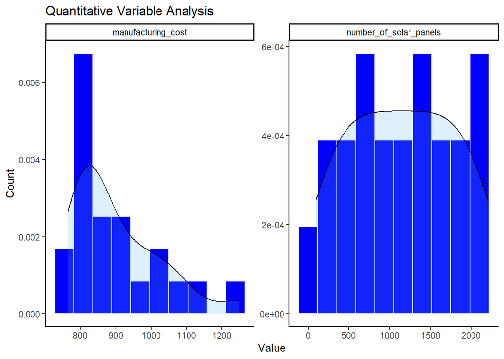

```r
histogram <- ggplot(gather(data = helio),aes(x = value)) +
  geom_histogram(aes(y = ..density..),bins = 10, color = "white", fill = "blue") + # Creates bin sizing & sets line color
  geom_density(alpha = .2, fill = "#56B4E9") +
  facet_wrap(~key,scales = "free") + # Converting the graphs into panels
  ggtitle("Quantitative Variable Analysis") + # Title name
  ylab("Count") + xlab("Value") + # Label names
  theme_classic() # A classic theme, with x and y axis lines and no grid lines

histogram
```

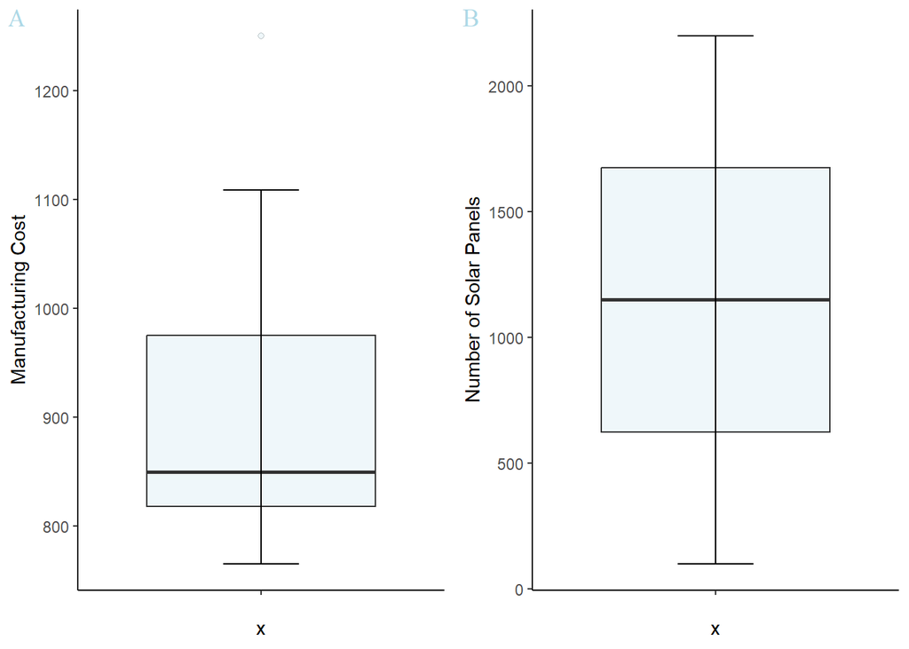

```r
# Using ggplot to create two boxplots with various features
MF_cost.box <- ggplot(data = helio, aes(x = "",y = manufacturing_cost)) +
    geom_boxplot(fill = "lightblue", alpha=0.2, outlier.shape = 21, outlier.color = "black") +
    stat_boxplot(geom = 'errorbar', linetype=1, width=0.25) +
    ylab("Manufacturing Cost") + # Label names
    theme_classic() # A classic theme, no grid lines

Number_solar.box <- ggplot(data = helio, aes(x = "",y = number_of_solar_panels)) +
    geom_boxplot(fill = "lightblue", alpha=0.2, outlier.shape = 21, outlier.color = "black") +
    stat_boxplot(geom = 'errorbar', linetype=1, width=0.25) +
    ylab("Number of Solar Panels") + # Label names
    theme_classic() # A classic theme, no grid lines

# Places the graphs into one space
plot_grid(MF_cost.box, Number_solar.box, labels = "AUTO",
  label_fontfamily = "serif",
  label_fontface = "plain",
  label_colour = "lightblue")
```

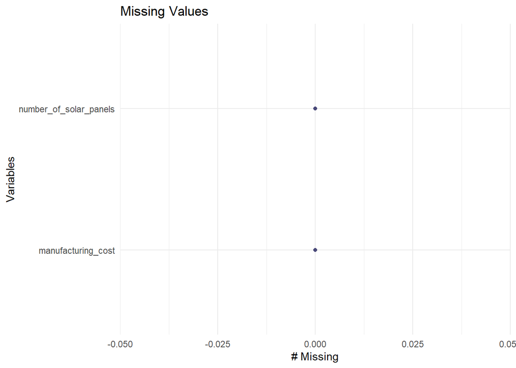

```r
# Missing values analysis
gg_miss_var(helio) + ggtitle("Missing Values")
```

## Question 1

Use an electronic spreadsheet to plot the data displayed in table 1 and draw a scatter plot (point diagram). Does the multiplicative learning model which assumes the following relationship: $Y = AX^b$ apply to this data set? In our case $Y$ are the average manufacturing cost of the last batch of 100 solar panels at Heliotronic in $ after having produced a cumulative production of $X$ solar panels. In the table $X$ represents the column labeled total number of solar panels produced at Heliotronics. $b$ is the experience parameter not to be confused with the learning rate. $X$ is the price or cost of the first unit. Obviously $Y = AX^b$ is not a linear relationship of the type that regression analysis can model $Y = a + b_1x_1$. So the question now is to transform the data in order to get a linear relationship. Make an appropriate transformation of the data and redo the plot with the transformed data.

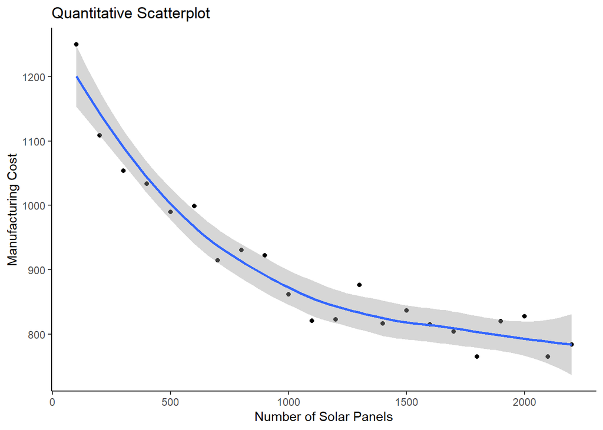

```r
# Create scatterplot with original values
ggplot(helio, aes(number_of_solar_panels, manufacturing_cost) ) +
  geom_point()+
  geom_smooth() +
  ggtitle("Quantitative Scatterplot") +
  ylab("Manufacturing Cost") + # Label names
  xlab("Number of Solar Panels") + # Label names
  theme_classic() # A classic theme, no grid lines
```

A multiplicative learning model assumes the relationship of $Y = AX^b$. This model is non-linear, and follows the assumption that as the cost of manufacturing decreases, the number of units produced increases. This is seen above as their relationship is inversely related. The goal of modeling this data is to fit a linear equation to show the relationship between the independent variable (‘number of solar panels’) and the dependent (‘manufacturing cost’) to predict price per some ‘x’ amount of units.

- $Y$: The inflation-adjusted production cost per unit of a product
- $X$: The total cumulative production of a product
- $b$: The experience parameter not to be confused with the learning rate
- $A$: The production cost of the first unit

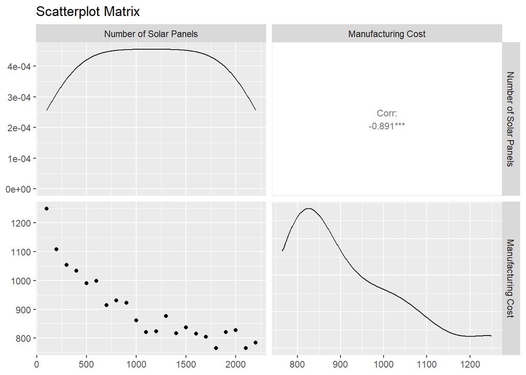

```r
# Used ggpairs to create a scatterplot matrix
ggpairs(helio, title = "Scatterplot Matrix",
    columns = 1:2,
    proportions = "auto",
    columnLabels = c("Number of Solar Panels","Manufacturing Cost"),
    upper = list(continuous = wrap('cor',size = 3)),)
```

```r
# Log transform quantative variables
helio = helio |>  mutate(Log_number = log10(number_of_solar_panels))
helio = helio |>  mutate(Log_cost = log10(manufacturing_cost))
```

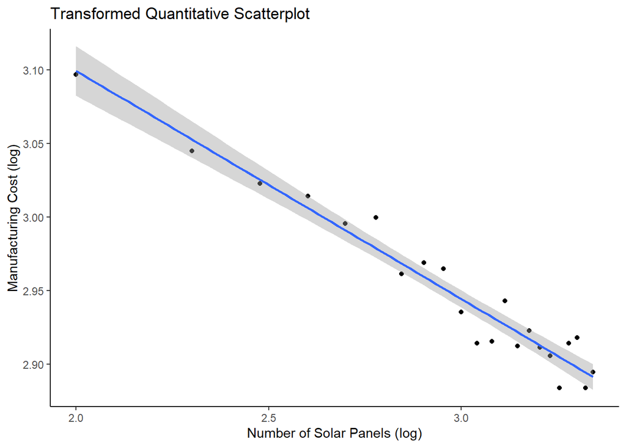

```r
# Create scatterplot with original values
ggplot(helio, aes(Log_number, Log_cost) ) +
  geom_point()+
  geom_smooth(method = "lm") +
  ggtitle("Transformed Quantitative Scatterplot") +
  ylab("Manufacturing Cost (log)") + # Label names
  xlab("Number of Solar Panels (log)") + # Label names
  theme_classic() # A classic theme, no grid lines
```

To address the problem of non-linearity, transformation of the variables may improve the accuracy of the model. The method used for the predictor and explanatory variable is taking the log. These two new values are added into the data frame and can be remodeled to show the inverse relationship through a linear regression. Now, the model aligns with $Y = a + b_1x_1$.

## Question 2

Once you have answered the above questions, conduct a linear regression with the transformed data: Use `R` to estimate the regression model. Please interpret the results of the regression analysis! How well does the model explain the data? What is the learning rate that applies in this case?

```r
# Linear regression
lin_reg_helio = with(helio,lm(Log_cost ~ Log_number))
summary(lin_reg_helio)
```

```
##
## Call:
## lm(formula = Log_cost ~ Log_number)
##
## Residuals:
##       Min        1Q    Median        3Q       Max
## -0.023675 -0.008668 -0.001944  0.009214  0.020800
##
## Coefficients:
##              Estimate Std. Error t value Pr(>|t|)
## (Intercept)  3.409353   0.023629  144.28  < 2e-16 ***
## Log_number  -0.154991   0.007936  -19.53  1.7e-14 ***
## ---
## Signif. codes:  0 '***' 0.001 '**' 0.01 '*' 0.05 '.' 0.1 ' ' 1
##
## Residual standard error: 0.01299 on 20 degrees of freedom
## Multiple R-squared:  0.9502, Adjusted R-squared:  0.9477
## F-statistic: 381.4 on 1 and 20 DF,  p-value: 1.701e-14
```

```r
r_squared <- summary(lin_reg_helio)$r.squared # Computed for Tolerance value and VIF
```

### Assumption Violations

**Variance Inflation Factors**

```r
# Compute the VIF value (explained)
VIF = 1/(1-r_squared)
VIF
```

```
## [1] 20.0694
```

```r
# Compute the tolerance value (unique)
tolerance_value = 1 - r_squared
tolerance_value
```

```
## [1] 0.0498271
```

To properly analyze the results in the table above, we need to ensure that the variables to not exceed the average of VIF. Multicollinearity is present when certain VIF are larger than 5 or 10. The VIF in this data definitely exceeds at 20.07, showing signs of multicollinearity between the number of solar panels and manufacturing cost. Additionally, the tolerance value or unique variance is approximately 5.0%, while the explained would be roughly 95.0%. **Therefore, we can conclude we do have to do a model selection.**

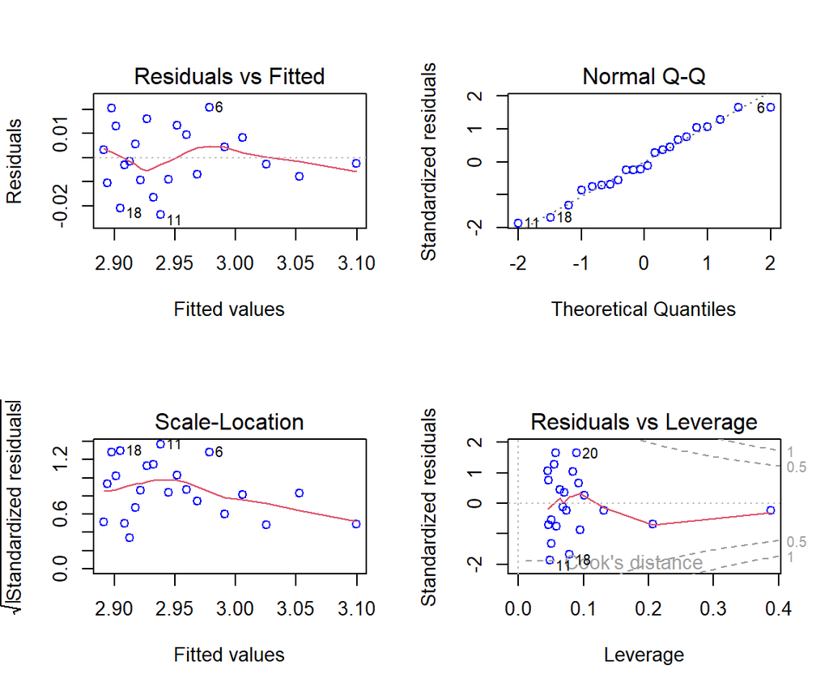

```r
par(mfrow = c(2,2)) # Organizes graphs in a specific order
plot(lin_reg_helio, col = "blue") # Plots the linear regression
```

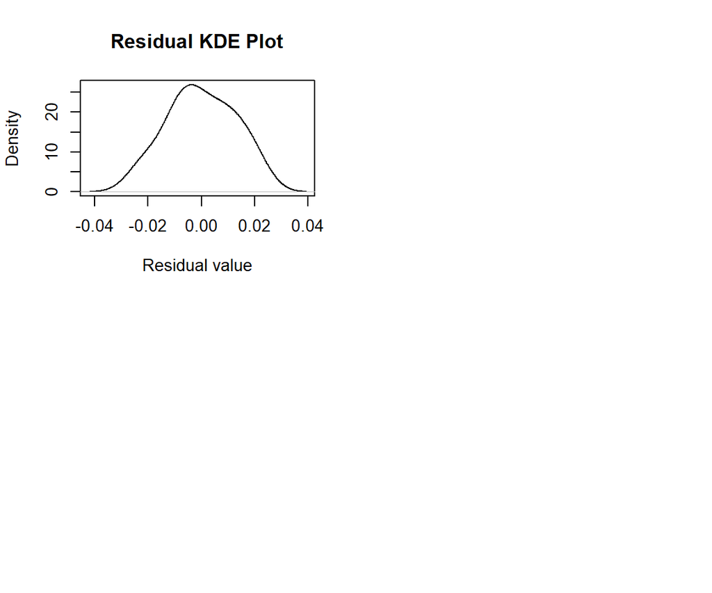

```r
d <- density(lin_reg_helio[['residuals']])
plot(d, main = 'Residual KDE Plot',xlab = 'Residual value')
```

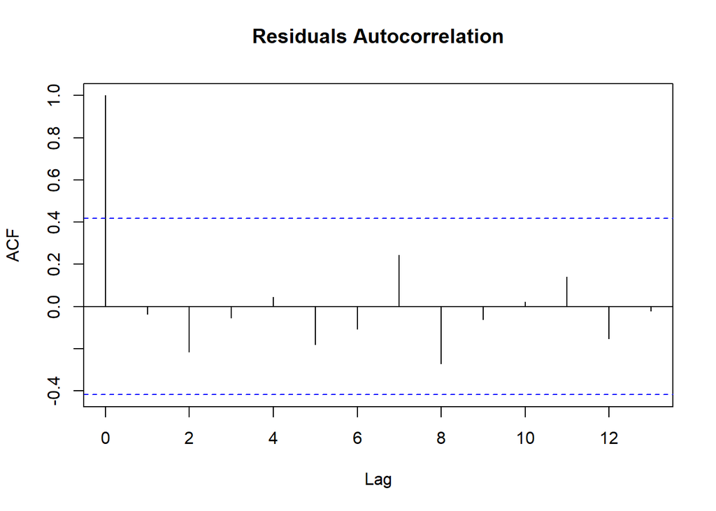

```r
# Function to graph autocorrelations
acf(resid(lin_reg_helio), main = "Residuals Autocorrelation")
```

- A residual will be considered large if its absolute value exceeds (approximately) 2σ(hat)
- When n is large, a residual will be considered large if its absolute value exceeds (approximately) 4σ(hat) (otherwise, too many residues will be considered large!)

There do appear to be three outliers (6, 11, and 18) and possibly heteroskedasticity as most residuals are grouped to the left and fewer are shown to the right which is considered non-constant.

**Normal Q-Q**  
To check the normality of the errors $ε_i$, analyze a normal Q-Q plot of the residuals. There appears to be a zigzag-like pattern in the residuals. This is reasonable enough to say that the points approximately fall on the line due to the KDE plot. In that chart, it is close to normality, but skews a little to the right. In addition, there is some departure by each of the tails, which are three outliers. The data is assumed to be normally distributed by its roughly “bell shaped” curve.

**Scale-Location**  
As seen in the other graphs, there are extreme residuals. We know that this is considered extreme because of the following: 2xσ.

**Autocorrelation**  
The ACF plot shows that there is no evidence of autocorrelation between the residuals as the lags do not exceed the confidence interval.

## Question 3

Please use the experience curve estimate from the regression model to calculate the expected average manufacturing cost per solar panel for the 400 solar panels that would be produced. for Switzerland. *Hint*: estimate the average production cost per solar panel for 4700, 4800, 4900 and 5000 units and compute their mean.

```r
# predict the cost of manufacturing 4700, 4800, 4900, and 5000 solar panels
#x <-  c(4700, 4800, 4900, 5000)
#y_pred <- predict(lin_reg_helio, newdata = x)

# compute the mean of the predicted costs
#mean_cost <- mean(y_pred)
#mean_cost
```

[output not shown]

## Question 4

Please calculate a 95% confidence interval for the average manufacturing cost per solar panel for the panels produced for Switzerland by using the lower and upper bounds of the confidence interval estimate for the experience parameter. You should calculate two extra regression equations for both limits and then calculate the expected average manufacturing cost per solar panel for the 400 solar panels that would be produced for Switzerland as in exercise 3.

```r
# Computing confidence intervals for one or more parameters in a fitted model
CI = confint(lin_reg_helio)
CI
```

```
##                  2.5 %     97.5 %
## (Intercept)  3.3600629  3.4586432
## Log_number  -0.1715456 -0.1384356
```